# Most harmful events in the US in terms of population health and economic consequences

Ben de Haan

24 Jul 2014

## Synopsis

Two questions must be answered:

1. Across the United States, which types of events are most harmful with respect to population health?
2. Across the United States, which types of events have the greatest economic consequences?

To accomplish this, the storm database from the US National Oceanic and Atmospheric Administration’s (NOAA) was examined. To answer the first question, average injuries and fatalities per event type were computed. For the second question, average property and crop damage per event type were computed.

Most harmful to health in terms of fatalities were: ‘Tornadoes, thunderstorm wind and hail’, followed by ‘cold and snow’ and ‘tropical storm gordon’. In terms of injuries, the most dangerous event was ‘heat wave’, followed by ‘tropical storm gordon’ and ‘wild fires.’ Events most costly in terms of money were: ‘tornadoes, thunderstorm wind and hail’, followed by ‘heavy rain/severe weather’ and ‘hurricane/typhoon.’ The most costly event type in terms of both fatalities and economic cost was ‘tornadoes, thunderstorm wind and hail.’

## Data processing

First, some libraries have to be initialized.

```r
library(knitr)
library(lattice)
```

### Loading the data and reading in data

Data was downloaded from `https://d396qusza40orc.cloudfront.net/repdata%2Fdata%2FStormData.csv.bz2` and unzipped.

```r
if(!file.exists("stormdata.csv.bz2")){
    download.file(
        url = "https://d396qusza40orc.cloudfront.net/repdata%2Fdata%2FStormData.csv.bz2",
        destfile = "stormdata.csv.bz2",
        method = "curl")}
```

Documentation can be found on `https://d396qusza40orc.cloudfront.net/repdata%2Fpeer2_doc%2Fpd01016005curr.pdf`.

For the FAQ, check `https://d396qusza40orc.cloudfront.net/repdata%2Fpeer2_doc%2FNCDC%20Storm%20Events-FAQ%20Page.pdf`

Reading in the data was done as follows:

```r
stormdata <- read.table("stormdata.csv", header = TRUE, sep = ",")
```

After reading in, dimensions were checked. Reading in resulted in 902297 rows and 37 columns.

```r
dim(stormdata)
```

```
## [1] 902297     37
```

```r
head(stormdata)
```

```
##   STATE__           BGN_DATE BGN_TIME TIME_ZONE COUNTY COUNTYNAME STATE
## 1       1  4/18/1950 0:00:00     0130       CST     97     MOBILE    AL
## 2       1  4/18/1950 0:00:00     0145       CST      3    BALDWIN    AL
## 3       1  2/20/1951 0:00:00     1600       CST     57    FAYETTE    AL
## 4       1   6/8/1951 0:00:00     0900       CST     89    MADISON    AL
## 5       1 11/15/1951 0:00:00     1500       CST     43    CULLMAN    AL
## 6       1 11/15/1951 0:00:00     2000       CST     77 LAUDERDALE    AL
##    EVTYPE BGN_RANGE BGN_AZI BGN_LOCATI END_DATE END_TIME COUNTY_END
## 1 TORNADO         0                                               0
## 2 TORNADO         0                                               0
## 3 TORNADO         0                                               0
## 4 TORNADO         0                                               0
## 5 TORNADO         0                                               0
## 6 TORNADO         0                                               0
##   COUNTYENDN END_RANGE END_AZI END_LOCATI LENGTH WIDTH F MAG FATALITIES
```

[output cut: 20 more lines]

```r
str(stormdata)
```

```
## 'data.frame':    902297 obs. of  37 variables:
##  $ STATE__   : num  1 1 1 1 1 1 1 1 1 1 ...
##  $ BGN_DATE  : Factor w/ 16335 levels "1/1/1966 0:00:00",..: 6523 6523 4242 11116 2224 2224 2260 383 3980 3980 ...
##  $ BGN_TIME  : Factor w/ 3608 levels "00:00:00 AM",..: 272 287 2705 1683 2584 3186 242 1683 3186 3186 ...
##  $ TIME_ZONE : Factor w/ 22 levels "ADT","AKS","AST",..: 7 7 7 7 7 7 7 7 7 7 ...
##  $ COUNTY    : num  97 3 57 89 43 77 9 123 125 57 ...
##  $ COUNTYNAME: Factor w/ 29601 levels "","5NM E OF MACKINAC BRIDGE TO PRESQUE ISLE LT MI",..: 13513 1873 4598 10592 4372 10094 1973 23873 24418 4598 ...
##  $ STATE     : Factor w/ 72 levels "AK","AL","AM",..: 2 2 2 2 2 2 2 2 2 2 ...
##  $ EVTYPE    : Factor w/ 985 levels "   HIGH SURF ADVISORY",..: 834 834 834 834 834 834 834 834 834 834 ...
##  $ BGN_RANGE : num  0 0 0 0 0 0 0 0 0 0 ...
##  $ BGN_AZI   : Factor w/ 35 levels "","  N"," NW",..: 1 1 1 1 1 1 1 1 1 1 ...
##  $ BGN_LOCATI: Factor w/ 54429 levels ""," Christiansburg",..: 1 1 1 1 1 1 1 1 1 1 ...
##  $ END_DATE  : Factor w/ 6663 levels "","1/1/1993 0:00:00",..: 1 1 1 1 1 1 1 1 1 1 ...
##  $ END_TIME  : Factor w/ 3647 levels ""," 0900CST",..: 1 1 1 1 1 1 1 1 1 1 ...
##  $ COUNTY_END: num  0 0 0 0 0 0 0 0 0 0 ...
```

[output cut: 23 more lines]

```r
# Compute average fatalities per event type
avgFatalities <- aggregate(FATALITIES ~ EVTYPE, stormdata, mean)

# Create top ten
avgFatalitiesOrdered <- avgFatalities[order(avgFatalities$FATALITIES, decreasing = TRUE), ]
topTenAvgFatalities <- avgFatalitiesOrdered[1:10,]

# Compute average injuries per event type
avgInjuries <- aggregate(INJURIES ~ EVTYPE, stormdata, mean)

# Create top ten
avgInjuriesOrdered <- avgInjuries[order(avgInjuries$INJURIES, decreasing = TRUE), ]
topTenAvgInjuries <- avgInjuriesOrdered[1:10,]
```

Pre-processing economic damage required combining PROPDMG and PROPDMGEXP as well as CROPDMG and CROPDMGEXP. PROPDMG and CROPDMG were interpreted as an amount of dollars. For PROPDMGEXP and CROPDMGEXP, the values ‘H’, ‘K’, ‘M’ and ‘B’ were interpreted as multipliers of one hundred, one thousand, one million and one billion respectively. PROPDMGEXP and CROPDMGEXP values that did not comply to one of these multipliers were treated as a multiplier of 1.

The function to convert multipliers to numeric values is presented below.

```r
convertMultiplier <- function(x) {
    multiplier = 1

    if(x == "h" | x == "H"){
        multiplier = 100
    } else if (x == "k" | x == "K") {
        multiplier = 1000
    } else if (x == "m" | x == "M") {
        multiplier = 1000000
    } else if (x == "b" | x == "B") {
        multiplier = 1000000000
    }

    multiplier
}

# Convert property damage multiplier
propDmgMultiplier <- sapply(stormdata$PROPDMGEXP, convertMultiplier)

# Convert crop damage multiplier
cropDmgMultiplier <- sapply(stormdata$CROPDMGEXP, convertMultiplier)

# Calculate property damage
propDmg <- propDmgMultiplier * stormdata$PROPDMG

# Calculate crop damage
cropDmg <- cropDmgMultiplier * stormdata$CROPDMG
```

The crop and property damage were combined to a total amount of damage and then sorted to create a top 10.

```r
# Calculate total damage
totalDmg <- propDmg + cropDmg

# Add total damage to storm data
stormdataWithDmg <- cbind(stormdata, totalDmg)

# Compute average damage per event type
avgDamage <- aggregate(totalDmg ~ EVTYPE, stormdataWithDmg, mean)

# Create top ten
avgDamageOrdered <- avgDamage[order(avgDamage$totalDmg, decreasing = TRUE), ]
topTenAvgDamage <- avgDamageOrdered[1:10,]
```

## Results

### Summary statistics

```r
summary(stormdata$FATALITIES)
```

```
##    Min. 1st Qu.  Median    Mean 3rd Qu.    Max.
##       0       0       0       0       0     583
```

```r
summary(stormdata$INJURIES)
```

```
##    Min. 1st Qu.  Median    Mean 3rd Qu.    Max.
##     0.0     0.0     0.0     0.2     0.0  1700.0
```

```r
summary(stormdata$PROPDMG)
```

```
##    Min. 1st Qu.  Median    Mean 3rd Qu.    Max.
##       0       0       0      12       0    5000
```

```r
summary(stormdata$CROPDMG)
```

```
##    Min. 1st Qu.  Median    Mean 3rd Qu.    Max.
##     0.0     0.0     0.0     1.5     0.0   990.0
```

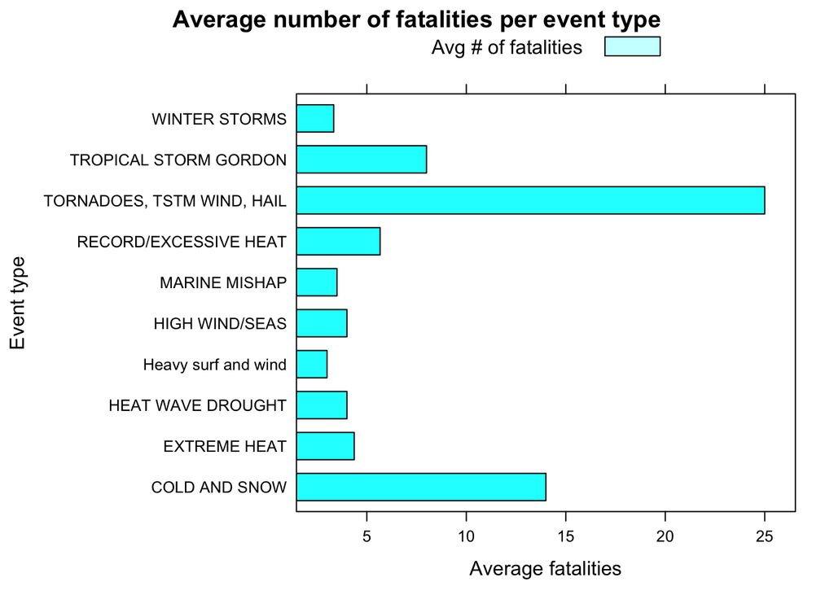

```r
barchart(topTenAvgFatalities$EVTYPE ~ topTenAvgFatalities$FATALITIES,
         xlab = "Average fatalities",
         ylab = "Event type",
         main = "Average number of fatalities per event type",
         auto.key=list(space="top",
                       columns=1,
                       cex.title=1,
                       text = "Avg # of fatalities"
                       )
         )
```

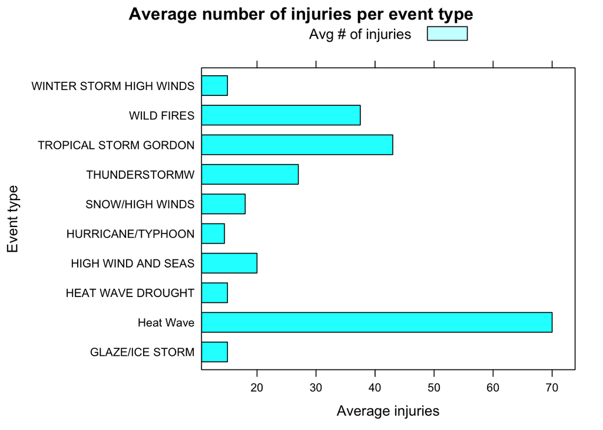

```r
barchart(topTenAvgInjuries$EVTYPE ~ topTenAvgInjuries$INJURIES,
         xlab = "Average injuries",
         ylab = "Event type",
         main = "Average number of injuries per event type",
         auto.key=list(space="top",
                       columns=1,
                       text = "Avg # of injuries"
                       )
         )
```

As seen from the graph, the most dangerous event in terms of fatalities is ‘Tornadoes, thunderstorm wind and hail’, followed by ‘cold and snow’ and ‘tropical storm gordon.’ In terms of injuries, the most dangerous event is ‘heat wave’, followed by ‘tropical storm gordon’ and ‘wild fires.’

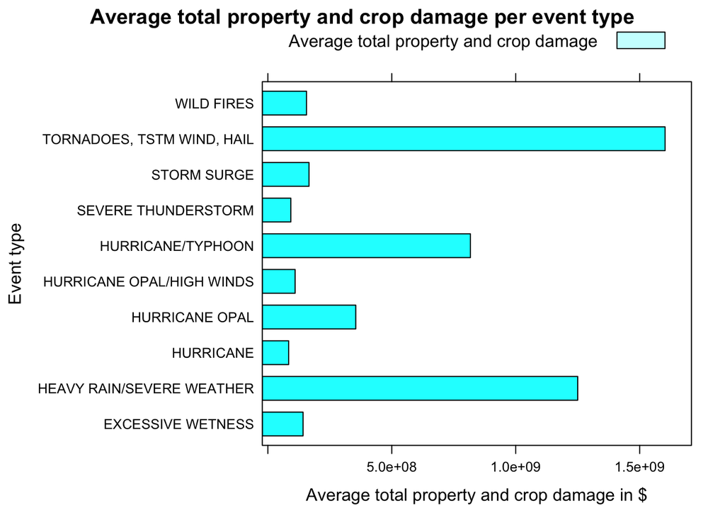

```r
barchart(topTenAvgDamage$EVTYPE ~ topTenAvgDamage$totalDmg,
         xlab = "Average total property and crop damage in $",
         ylab = "Event type",
         main = "Average total property and crop damage per event type",
         auto.key=list(space="top",
                       columns=1,
                       text = "Average total property and crop damage"
                       )
         )
```

In terms of economic cost, ‘tornadoes, thunderstorm wind and hail’ takes first place, followed by ‘heavy rain/severe weather’ and ‘hurricane/typhoon.’

## Conclusion

For both the economic cost and fatalities, ‘tornadoes, thunderstorm wind and hail’ was most dangerous. The total damage is subject to errors made when inputting the data, so results should be interpreted with caution.